# Using tidymodels to Predict Health Insurance Cost

## Importação das Bibliotecas

```r
library(tidyverse)
library(tidymodels)
library(data.table)
library(skimr)
library(GGally)
library(kknn)
```

# Lendo o Dataset

```r
download.file("https://raw.githubusercontent.com/stedy/Machine-Learning-with-R-datasets/master/insurance.csv",
              "insurance.csv")
insur_dt <- fread("insurance.csv")
```

# Colunas do dataset

```r
insur_dt %>% colnames()
```

```
## [1] "age"      "sex"      "bmi"      "children" "smoker"   "region"   "charges"
```

# Descrição estatística da coluna “age” (idade)

```r
insur_dt$age %>% summary()
```

```
##    Min. 1st Qu.  Median    Mean 3rd Qu.    Max.
##   18.00   27.00   39.00   39.21   51.00   64.00
```

# Distribuição referente à coluna “sex” (sexo)

```r
insur_dt$sex %>% table()
```

```
## .
## female   male
##    662    676
```

# Descrição estatística da coluna “bmi” (Índice de massa corporal)

```r
insur_dt$bmi %>% summary()
```

```
##    Min. 1st Qu.  Median    Mean 3rd Qu.    Max.
##   15.96   26.30   30.40   30.66   34.69   53.13
```

# Distribuição referente à coluna “smoker” (fumante)

```r
insur_dt$smoker %>% table()
```

```
## .
##   no  yes
## 1064  274
```

# Descrição estatística da coluna “charges” (valor do seguro)

```r
insur_dt$charges %>% summary()
```

```
##    Min. 1st Qu.  Median    Mean 3rd Qu.    Max.
##    1122    4740    9382   13270   16640   63770
```

# Análise Exploratória de dados

```r
skimr::skim(insur_dt)
```

Data summary

| Name | insur_dt |
| --- | --- |
| Number of rows | 1338 |
| Number of columns | 7 |
| _______________________ |  |
| Column type frequency: |  |
| character | 3 |
| numeric | 4 |
| ________________________ |  |
| Group variables | None |

**Variable type: character**

| skim_variable | n_missing | complete_rate | min | max | empty | n_unique | whitespace |
| --- | --- | --- | --- | --- | --- | --- | --- |
| sex | 0 | 1 | 4 | 6 | 0 | 2 | 0 |
| smoker | 0 | 1 | 2 | 3 | 0 | 2 | 0 |
| region | 0 | 1 | 9 | 9 | 0 | 4 | 0 |

**Variable type: numeric**

| skim_variable | n_missing | complete_rate | mean | sd | p0 | p25 | p50 | p75 | p100 | hist |
| --- | --- | --- | --- | --- | --- | --- | --- | --- | --- | --- |
| age | 0 | 1 | 39.21 | 14.05 | 18.00 | 27.00 | 39.00 | 51.00 | 64.00 | ▇▅▅▆▆ |
| bmi | 0 | 1 | 30.66 | 6.10 | 15.96 | 26.30 | 30.40 | 34.69 | 53.13 | ▂▇▇▂▁ |
| children | 0 | 1 | 1.09 | 1.21 | 0.00 | 0.00 | 1.00 | 2.00 | 5.00 | ▇▂▂▁▁ |
| charges | 0 | 1 | 13270.42 | 12110.01 | 1121.87 | 4740.29 | 9382.03 | 16639.91 | 63770.43 | ▇▂▁▁▁ |

# Distribuição da tabela “children” (Numero de filhos)

```r
table(insur_dt$children)
```

```
##
##   0   1   2   3   4   5
## 574 324 240 157  25  18
```

## Utilização do pacote GGally, que facilita o processo de EDA gerando automaticamente ggplots com as variáveis do dataframe.

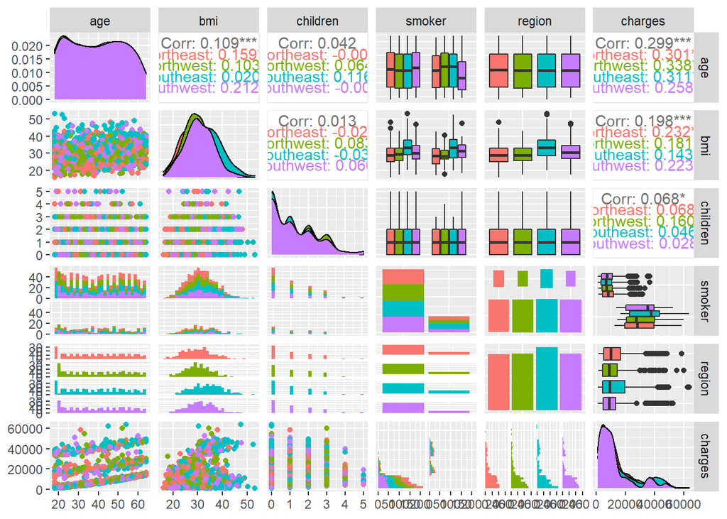

```r
options(repr.plot.width=15, repr.plot.height = 10)
insur_dt %>%
    select(age, bmi, children, smoker, region, charges) %>%
    GGally::ggpairs(mapping = aes(color = region))
```

# Mapa de relacionamento entre idade e valores de seguro pelas 4 regiões.

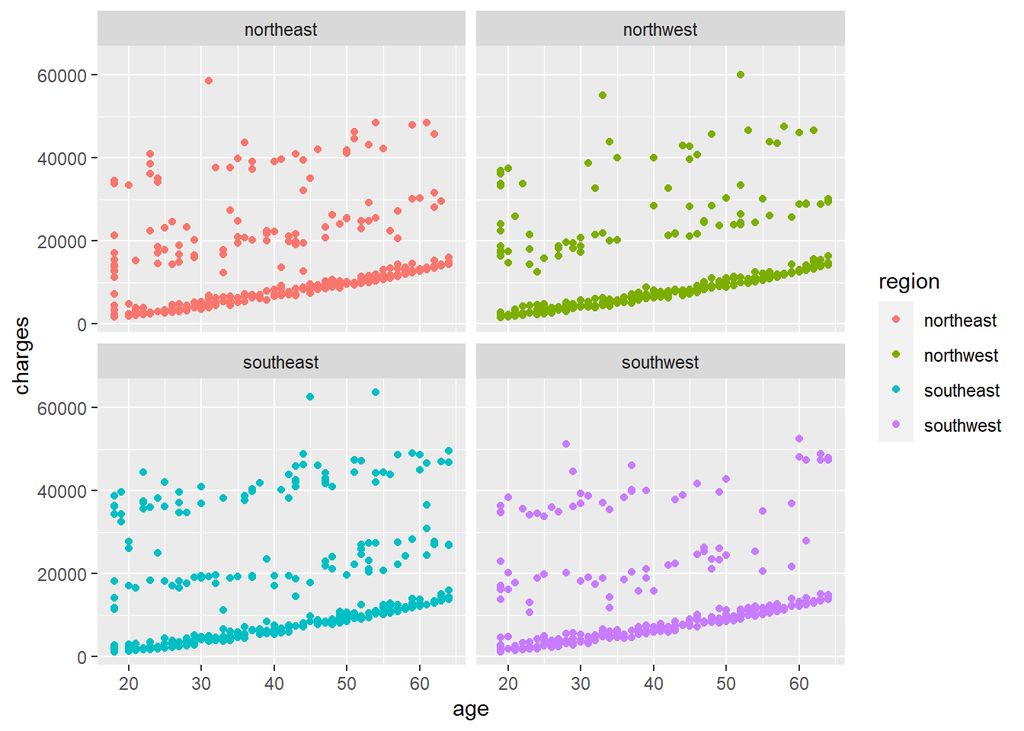

```r
insur_dt %>% ggplot(aes(color = region)) + facet_wrap(~ region)+
  geom_point(mapping = aes(x = age, y = charges))
```

## É possivel analisar que o preço fica próximo à linha do eixo X, aumentando levemente com a idade.

# Vamos para o fator que provavelmente mais irá impactar na cobertura do seguro de saúde: Smoker(fumante).

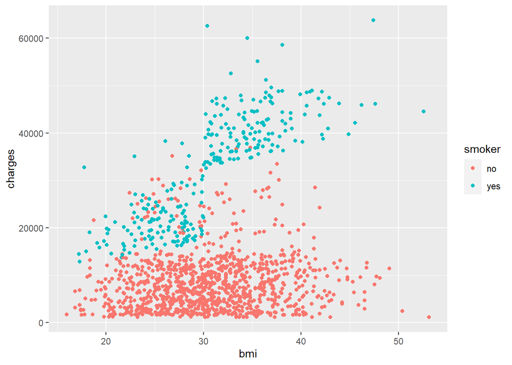

```r
insur_dt %>%
    select(smoker, bmi, charges) %>%
    ggplot(aes(color = smoker)) +
    geom_point(mapping = aes(x = bmi, y = charges))
```

## É possivel observar uma diferença marcante do preço dos que fumam para os que não fumam e tende a aumentar mais ainda em relação ao peso.

# Plot do peso em relação ao custo, evidênciando a faixa etária

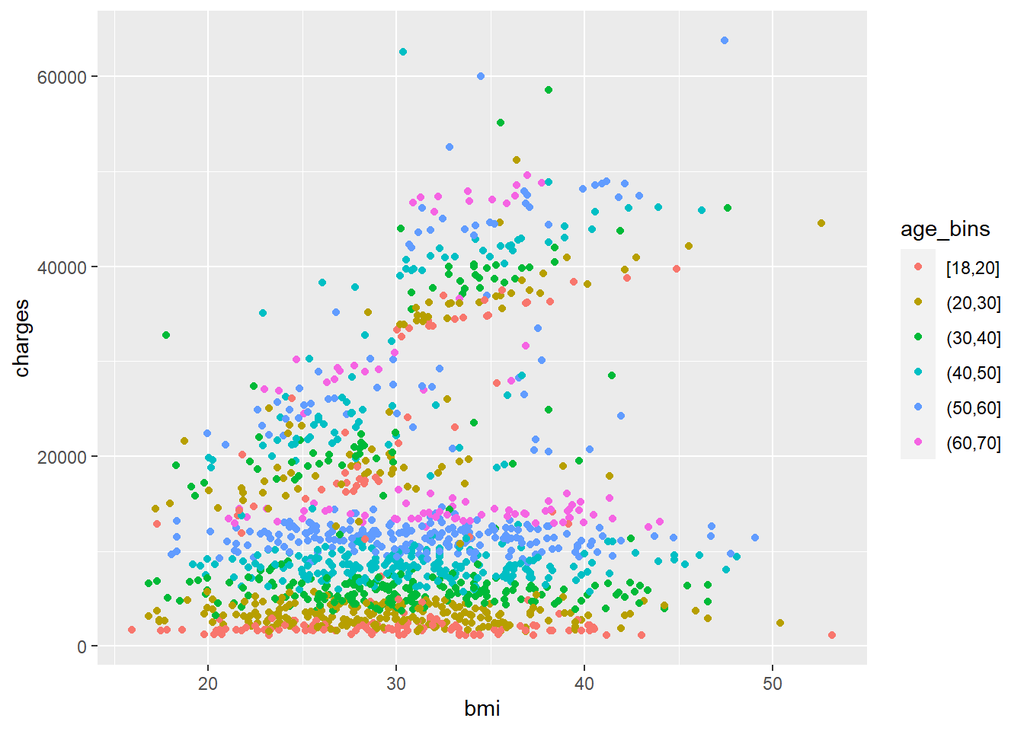

```r
insur_dt$age_bins <- cut(insur_dt$age,
                breaks = c(18,20,30,40,50,60,70,80,90),
                include.lowest = TRUE,
                right = TRUE)
insur_dt %>%
    select(bmi, charges, sex, age_bins) %>%
    ggplot(aes(color = age_bins)) +
    geom_point(mapping = aes(x = bmi, y = charges))
```

## É nítido que a idade impacta fortemente no valor, porém não parece interagir com o “bmi” ou “smoker”, isso significa que a idade afeta o valor independentemente.

# Análise dos filhos.

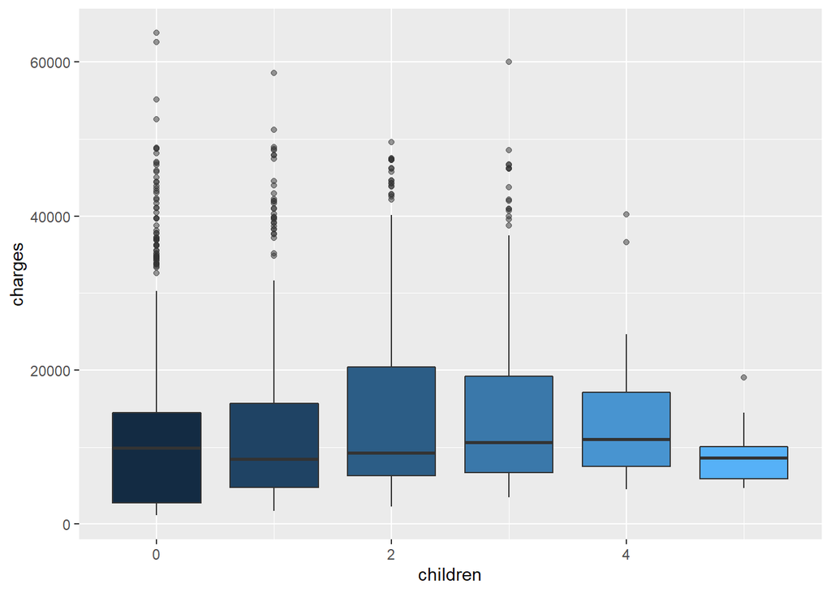

```r
insur_dt %>%
    select(children, charges, sex) %>%
    ggplot(aes(x = children, y = charges, group = children)) +
    geom_boxplot(outlier.alpha = 0.5, aes(fill = children)) +
    theme(legend.position = "none")
```

## A quantidade de filhos não afeta o valor significantemente.

# Criação do Modelo

### Primeiro é feita a divisão train/test, estratificando a coluna “smoker” por questões de equilibrio. “?”

```r
set.seed(123)
insur_split <- initial_split(insur_dt, strata = smoker)
insur_train <- training(insur_split)
insur_test <- testing(insur_split)
# we are going to do data processing and feature engineering with recipes
# below, we are going to predict charges using everything else(".")
insur_rec <- recipe(charges ~ bmi + age + smoker, data = insur_train) %>%
    step_dummy(all_nominal()) %>% #Criação de dummies para variáveis categóricas.
    step_normalize(all_numeric(), -all_outcomes()) %>% #Normalização dos dados
    step_interact(terms = ~ bmi:smoker_yes) #Termo de interação bmi e smoker_yes "?"
test_proc <- insur_rec %>% prep() %>% bake(new_data = insur_test)
```

# KNN - k-Nearest Neighbors

```r
knn_spec <- nearest_neighbor(neighbors = 10) %>%
    set_engine("kknn") %>%
    set_mode("regression")
knn_fit <- knn_spec %>%
    fit(charges ~ age + bmi + smoker_yes + bmi_x_smoker_yes,
        data = juice(insur_rec %>% prep()))
## Warning: partial match of 'object' to 'objects'
## Warning: partial match of 'object' to 'objects'
insur_wf <- workflow() %>%
    add_recipe(insur_rec) %>%
    add_model(knn_spec)
```

# Avaliação do modelo

```r
insur_cv <- vfold_cv(insur_train, prop = 0.9)

insur_rsmpl <- fit_resamples(insur_wf,
                           insur_cv,
                           control = control_resamples(save_pred = TRUE))
insur_rsmpl %>% collect_metrics()
```

| .metric | .estimator | mean | n | std_err | .config |
| --- | --- | --- | --- | --- | --- |
| rmse | standard | 4915.6510690 | 10 | 273.81343938 | Preprocessor1_Model1 |
| rsq | standard | 0.8270987 | 10 | 0.01938272 | Preprocessor1_Model1 |

### RSQ(R²) Sugere que a regressão tem um ajuste de ~82%.

# Demonstração do ajuste de regressão em uma linha:

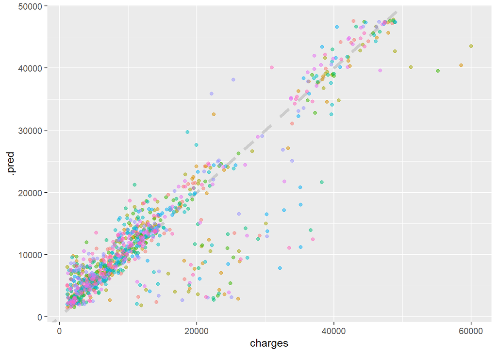

```r
insur_rsmpl %>%
    unnest(.predictions) %>%
    ggplot(aes(charges, .pred, color = id)) +
    geom_abline(lty = 2, color = "gray80", size = 1.5) +
    geom_point(alpha = 0.5) +
    theme(legend.position = "none")
```

# Aplicação do Modelo aos dados de teste definidos anteriormente.

```r
insur_test_res <- predict(knn_fit, new_data = test_proc %>% select(-charges))
## Warning: partial match of 'fit' to 'fitted.values'
insur_test_res <- bind_cols(insur_test_res, insur_test %>% select(charges))
insur_test_res
```

| .pred | charges |
| --- | --- |
| 4338.525 | 3756.622 |
| 27037.674 | 27808.725 |
| 2230.857 | 1837.237 |
| 6500.010 | 6203.902 |
| 2793.777 | 4687.797 |
| 6057.326 | 6313.759 |
| 14335.070 | 12629.897 |
| 1663.168 | 2211.131 |
| 5654.522 | 3579.829 |
| 39401.337 | 37742.576 |

[output cut: 324 more lines]

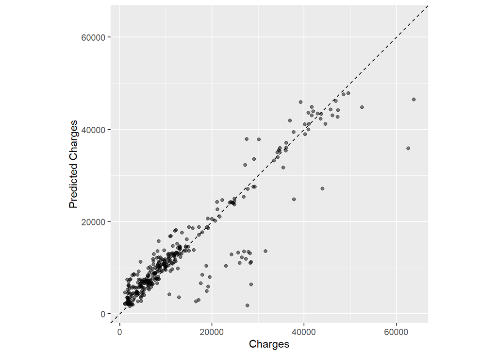

```r
ggplot(insur_test_res, aes(x = charges, y = .pred)) +
  # Create a diagonal line:
  geom_abline(lty = 2) +
  geom_point(alpha = 0.5) +
  labs(y = "Predicted Charges", x = "Charges") +
  # Scale and size the x- and y-axis uniformly:
  coord_obs_pred()
```

# Comparação:

```r
rmse(insur_test_res, truth = charges, estimate = .pred)
```

| .metric | .estimator | .estimate |
| --- | --- | --- |
| rmse | standard | 4985.013 |

```r
insur_rsmpl %>%
    collect_metrics()
```

| .metric | .estimator | mean | n | std_err | .config |
| --- | --- | --- | --- | --- | --- |
| rmse | standard | 4915.6510690 | 10 | 273.81343938 | Preprocessor1_Model1 |
| rsq | standard | 0.8270987 | 10 | 0.01938272 | Preprocessor1_Model1 |

### O RMSE Gerado pelos dados de teste é insignificantemente diferente daquele gerado pelo modelo KNN. Significa que o modelo pode reproduzir previsões de forma confiável.

# Regressão Linear

```r
lm_spec <- linear_reg() %>%
    set_engine("lm")
lm_fit <- lm_spec %>%
    fit(charges ~ age + bmi + smoker_yes + bmi_x_smoker_yes,
        data = juice(insur_rec %>% prep()))
## Warning: partial match of 'object' to 'objects'
## Warning: partial match of 'object' to 'objects'
insur_lm_wf <- workflow() %>%
    add_recipe(insur_rec) %>%
    add_model(lm_spec)
```

# Validação do modelo

```r
insur_lm_rsmpl <- fit_resamples(insur_lm_wf,
                           insur_cv,
                           control = control_resamples(save_pred = TRUE))

insur_lm_rsmpl %>%
    collect_metrics()
```

| .metric | .estimator | mean | n | std_err | .config |
| --- | --- | --- | --- | --- | --- |
| rmse | standard | 4866.2198826 | 10 | 251.33407535 | Preprocessor1_Model1 |
| rsq | standard | 0.8321469 | 10 | 0.01622478 | Preprocessor1_Model1 |

```r
insur_rsmpl %>%
    collect_metrics()
```

| .metric | .estimator | mean | n | std_err | .config |
| --- | --- | --- | --- | --- | --- |
| rmse | standard | 4915.6510690 | 10 | 273.81343938 | Preprocessor1_Model1 |
| rsq | standard | 0.8270987 | 10 | 0.01938272 | Preprocessor1_Model1 |

## Comparando os dois modelos é possivel observar que o de regressão linear é ainda melhor que o KNN, tanto em RMSE quanto em R².

```r
insur_test_lm_res <- predict(lm_fit, new_data = test_proc %>% select(-charges))
insur_test_lm_res <- bind_cols(insur_test_lm_res, insur_test %>% select(charges))
insur_test_lm_res
```

| .pred | charges |
| --- | --- |
| 6334.798 | 3756.622 |
| 31937.879 | 27808.725 |
| 3171.162 | 1837.237 |
| 7877.760 | 6203.902 |
| 3080.535 | 4687.797 |
| 7814.887 | 6313.759 |
| 14070.085 | 12629.897 |
| 2655.583 | 2211.131 |
| 3498.149 | 3579.829 |
| 36293.062 | 37742.576 |

[output cut: 324 more lines]

## Visualização gráfica da regressão linear

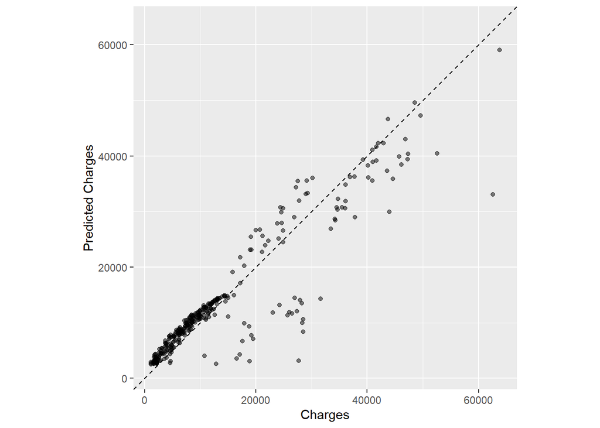

```r
ggplot(insur_test_lm_res, aes(x = charges, y = .pred)) +
  # Create a diagonal line:
  geom_abline(lty = 2) +
  geom_point(alpha = 0.5) +
  labs(y = "Predicted Charges", x = "Charges") +
  # Scale and size the x- and y-axis uniformly:
  coord_obs_pred()
```

# Comparação entre os dois métodos:

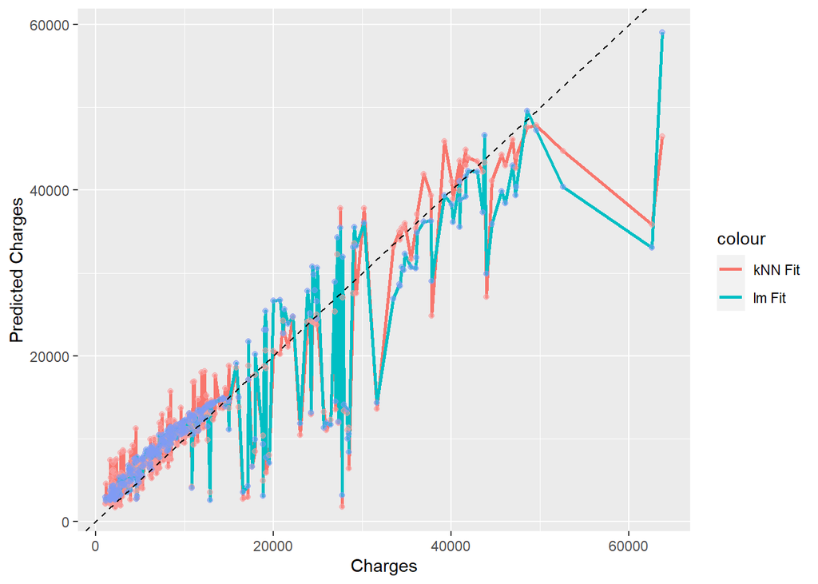

```r
combind_dt <- mutate(insur_test_lm_res,
      lm_pred = .pred,
      charges = charges
      ) %>% select(-.pred) %>%
    add_column(knn_pred = insur_test_res$.pred)
ggplot(combind_dt, aes(x = charges)) +
    geom_line(aes(y = knn_pred, color = "kNN Fit"), size = 1) +
    geom_line(aes(y = lm_pred, color = "lm Fit"), size = 1) +
    geom_point(aes(y = knn_pred, alpha = 0.5), color = "#F99E9E") +
    geom_point(aes(y = lm_pred, alpha = 0.5), color = "#809BF4") +
    geom_abline(size = 0.5, linetype = "dashed") +
    xlab('Charges') +
    ylab('Predicted Charges') +
    guides(alpha = FALSE)
```